# SurveyMonkey Example Data Analysis

Zack Crowley

2024-07-08

# Data Cleaning and Manipulation

## Importing data from SurveyMonkey

Our current survey provider is [SurveyMonkey](https://www.surveymonkey.com/?ut_source=homepage&ut_source3=header), `blackstone` contains several functions that makes the process of reading SurveyMonkey data into `R` a more manageable process and creates a codebook for the data along the way.

SurveyMonkey exports data with two header rows, which does not work with `R` where tibbles and dataframes can only have one row of names.

Here is how to import data from SurveyMonkey using example data provided with `blackstone`, this is a fake dataset of a pre (baseline) survey. There are three steps to this process:

1. Create a codebook.

```r
# File path for pre example data:
pre_data_fp <- blackstone::blackstoneExample("sm_data_pre.csv")
# 1. Create the codebook:
codebook_pre <- blackstone::createCodebook(pre_data_fp)
codebook_pre
```

```
## # A tibble: 32 × 5
##    header_1                      header_2 combined_header position variable_name
##    <chr>                         <chr>    <chr>              <int> <chr>
##  1 Respondent ID                 <NA>     Respondent ID          1 respondent_id
##  2 Collector ID                  <NA>     Collector ID           2 collector_id
##  3 Start Date                    <NA>     Start Date             3 start_date
##  4 End Date                      <NA>     End Date               4 end_date
##  5 IP Address                    <NA>     IP Address             5 ip_address
##  6 Email Address                 <NA>     Email Address          6 email_address
##  7 First Name                    <NA>     First Name             7 first_name
##  8 Last Name                     <NA>     Last Name              8 last_name
##  9 Custom Data 1                 <NA>     Custom Data 1          9 custom_data_1
## 10 To what extent are you knowl… <NA>     To what extent…       10 to_what_exte…
## # ℹ 22 more rows
```

For this codebook, the first column `header_1` is the first header from the SurveyMonkey data, the second column `header_2` is the second header, the third column `combined_header` is the combination of the two headers, `position` is the column number position for each `combined_header`, and `variable_name` is a cleaned up version for `combined_header` and will be the column to edit to change the column names later on to shorter and more meaningful names.

`variable_name` will be the column that renames all the variables in the SurveyMonkey data.

2. Edit the codebook to create meaningful variable names.

```r
# Step 2. Edit the codebook:
# Set up sequential naming convections for matrix-style questions with shared likert scale response options:
# 8 items that are matrix-style likert scales- turned into a scale called `research`- here is how to easily name them all at once:
# Rows 11 to 18 belong to the "research" matrix question (you will have to look at the codebook and match the header_1 and header_2 to variable_name to change)
research_items <- codebook_pre[["variable_name"]][11:18]
research_names <- paste0("research_", seq_along(research_items)) %>% purrr::set_names(., research_items) # Create a new named vector of names for these columns
# 6 items that are matrix-style likert scales- turned into a scale called `ability`- Rows 19 to 24 named `variable_name`:
ability_items <- codebook_pre[["variable_name"]][19:24]
ability_names <- paste0("ability_", seq_along(ability_items)) %>% purrr::set_names(., ability_items) # Create a new named vector of names for these columns
# 6 items that are matrix-style likert scales- turned into a scale called `ethics`- Rows 19 to 24 named `variable_name`:
ethics_items <- codebook_pre[["variable_name"]][25:29]
ethics_names <- paste0("ethics_", seq_along(ethics_items)) %>% purrr::set_names(., ethics_items) # Create a new named vector of names for these columns
# Edit the `variable_names` column: Use dplyr::mutate() and dplyr::case_match() to change the column `variable_name`:
codebook_pre <- codebook_pre %>% dplyr::mutate(
    variable_name = dplyr::case_match(
        variable_name, # column to match
        'custom_data_1' ~ "unique_id", # changes 'custom_data_1' to "unique_id"
        'to_what_extent_are_you_knowledgeable_in_conducting_research_in_your_field_of_study' ~ "knowledge",
        'with_which_gender_do_you_most_closely_identify' ~ "gender",
        'which_race_ethnicity_best_describes_you_please_choose_only_one' ~ "ethnicity",
        'are_you_a_first_generation_college_student' ~ "first_gen",
        names(research_names) ~ research_names[variable_name], # takes the above named vector and when the name matches, applies new value in that position as replacement.
        names(ability_names) ~ ability_names[variable_name],   # Same for `ability_names`
        names(ethics_names) ~ ethics_names[variable_name],   # Same for `ability_names`
        .default = variable_name # returns default value from original `variable_name` if not changed.
        )
    )
codebook_pre
```

```
## # A tibble: 32 × 5
##    header_1                      header_2 combined_header position variable_name
##    <chr>                         <chr>    <chr>              <int> <chr>
##  1 Respondent ID                 <NA>     Respondent ID          1 respondent_id
##  2 Collector ID                  <NA>     Collector ID           2 collector_id
##  3 Start Date                    <NA>     Start Date             3 start_date
##  4 End Date                      <NA>     End Date               4 end_date
##  5 IP Address                    <NA>     IP Address             5 ip_address
##  6 Email Address                 <NA>     Email Address          6 email_address
##  7 First Name                    <NA>     First Name             7 first_name
##  8 Last Name                     <NA>     Last Name              8 last_name
##  9 Custom Data 1                 <NA>     Custom Data 1          9 unique_id
## 10 To what extent are you knowl… <NA>     To what extent…       10 knowledge
## # ℹ 22 more rows
```

```r
# Write out the edited codebook to save for future use-
# Be sure to double check questions match new names before writing out:
# readr::write_csv(codebook_pre, file = "{filepath-to-codebok}")
```

3. Read in the data and rename the variables with the codebook.

```r
# 3. Read in the data and rename the vars using readRenameData(), passing the file path and the edited codebook:
pre_data <- blackstone::readRenameData(pre_data_fp, codebook = codebook_pre)
pre_data
```

```
## # A tibble: 100 × 32
##    respondent_id collector_id start_date end_date   ip_address     email_address
##            <dbl>        <dbl> <date>     <date>     <chr>          <chr>
##  1  114628000001    431822954 2024-06-05 2024-06-06 227.224.138.1… coraima59@me…
##  2  114628000002    431822954 2024-06-21 2024-06-22 110.241.132.50 mstamm@hermi…
##  3  114628000003    431822954 2024-06-14 2024-06-15 165.58.112.64  precious.fei…
##  4  114628000004    431822954 2024-06-15 2024-06-16 49.34.121.147  ines52@gmail…
##  5  114628000005    431822954 2024-06-15 2024-06-16 115.233.66.80  franz44@hotm…
##  6  114628000006    431822954 2024-06-11 2024-06-12 17.228.99.90   gleichner.sy…
##  7  114628000007    431822954 2024-06-21 2024-06-22 32.194.52.180  elodie77@plc…
##  8  114628000008    431822954 2024-06-01 2024-06-02 58.79.96.90    chynna.winth…
##  9  114628000009    431822954 2024-06-11 2024-06-12 60.220.231.125 dwyane16@yah…
## 10  114628000010    431822954 2024-06-01 2024-06-02 243.66.50.214  joaquin.runo…
## # ℹ 90 more rows
## # ℹ 26 more variables: first_name <chr>, last_name <chr>, unique_id <dbl>,
## #   knowledge <chr>, research_1 <chr>, research_2 <chr>, research_3 <chr>,
## #   research_4 <chr>, research_5 <chr>, research_6 <chr>, research_7 <chr>,
## #   research_8 <chr>, ability_1 <chr>, ability_2 <chr>, ability_3 <chr>,
## #   ability_4 <chr>, ability_5 <chr>, ability_6 <chr>, ethics_1 <chr>,
## #   ethics_2 <chr>, ethics_3 <chr>, ethics_4 <chr>, ethics_5 <chr>, …
```

The SurveyMonkey example data is now imported with names taken from the codebook column `variable_name`:

```r
names(pre_data)
```

```
##  [1] "respondent_id" "collector_id"  "start_date"    "end_date"
##  [5] "ip_address"    "email_address" "first_name"    "last_name"
##  [9] "unique_id"     "knowledge"     "research_1"    "research_2"
## [13] "research_3"    "research_4"    "research_5"    "research_6"
## [17] "research_7"    "research_8"    "ability_1"     "ability_2"
## [21] "ability_3"     "ability_4"     "ability_5"     "ability_6"
## [25] "ethics_1"      "ethics_2"      "ethics_3"      "ethics_4"
## [29] "ethics_5"      "gender"        "ethnicity"     "first_gen"
```

## Post data:

```r
# File path for pre example data:
post_data_fp <- blackstone::blackstoneExample("sm_data_post.csv")
# 1. Create the codebook:
codebook_post <- blackstone::createCodebook(post_data_fp)
codebook_post
```

```
## # A tibble: 37 × 5
##    header_1                      header_2 combined_header position variable_name
##    <chr>                         <chr>    <chr>              <int> <chr>
##  1 Respondent ID                 <NA>     Respondent ID          1 respondent_id
##  2 Collector ID                  <NA>     Collector ID           2 collector_id
##  3 Start Date                    <NA>     Start Date             3 start_date
##  4 End Date                      <NA>     End Date               4 end_date
##  5 IP Address                    <NA>     IP Address             5 ip_address
##  6 Email Address                 <NA>     Email Address          6 email_address
##  7 First Name                    <NA>     First Name             7 first_name
##  8 Last Name                     <NA>     Last Name              8 last_name
##  9 Custom Data 1                 <NA>     Custom Data 1          9 custom_data_1
## 10 To what extent are you knowl… <NA>     To what extent…       10 to_what_exte…
## # ℹ 27 more rows
```

```r
# Step 2. Edit the codebook:
# Set up sequential naming convections for matrix-style questions with shared likert scale response options:
# 8 items that are matrix-style likert scales- turned into a scale called `research`- here is how to easily name them all at once:
# Rows 11 to 18 belong to the "research" matrix question (you will have to look at the codebook and match the header_1 and header_2 to variable_name to change)
research_items <- codebook_post[["variable_name"]][11:18]
research_names <- paste0("research_", seq_along(research_items)) %>% purrr::set_names(., research_items) # Create a new named vector of names for these columns
# 6 items that are matrix-style likert scales- turned into a scale called `ability`- Rows 19 to 24 named `variable_name`:
ability_items <- codebook_post[["variable_name"]][19:24]
ability_names <- paste0("ability_", seq_along(ability_items)) %>% purrr::set_names(., ability_items) # Create a new named vector of names for these columns
# 6 items that are matrix-style likert scales- turned into a scale called `ethics`- Rows 19 to 24 named `variable_name`:
ethics_items <- codebook_post[["variable_name"]][25:29]
ethics_names <- paste0("ethics_", seq_along(ethics_items)) %>% purrr::set_names(., ethics_items) # Create a new named vector of names for these columns
# 5 items that are Open-ended follow up when corresponeding ethics items were answered "Strongly disagree"or "Disagree"- Rows 30 to 34 named `variable_name`:
ethics_items_oe <- codebook_post[["variable_name"]][30:34]
ethics_names_oe <- paste0("ethics_", seq_along(ethics_items), "_oe") %>% purrr::set_names(., ethics_items_oe) # Create a new named vector of names for these columns
# Edit the `variable_names` column: Use dplyr::mutate() and dplyr::case_match() to change the column `variable_name`:
codebook_post <- codebook_post %>% dplyr::mutate(
    variable_name = dplyr::case_match(
        variable_name, # column to match
        'custom_data_1' ~ "unique_id", # changes 'custom_data_1' to "unique_id"
        'to_what_extent_are_you_knowledgeable_in_conducting_research_in_your_field_of_study' ~ "knowledge",
        'with_which_gender_do_you_most_closely_identify' ~ "gender",
        'which_race_ethnicity_best_describes_you_please_choose_only_one' ~ "ethnicity",
        'are_you_a_first_generation_college_student' ~ "first_gen",
        names(research_names) ~ research_names[variable_name], # takes the above named vector and when the name matches, applies new value in that position as replacement.
        names(ability_names) ~ ability_names[variable_name],   # Same for `ability_names`
        names(ethics_names) ~ ethics_names[variable_name],   # Same for `ability_names`
        names(ethics_names_oe) ~ ethics_names_oe[variable_name],   # Same for `ethics_names_oe`
        .default = variable_name # returns default value from original `variable_name` if not changed.
        )
    )
codebook_post
```

```
## # A tibble: 37 × 5
##    header_1                      header_2 combined_header position variable_name
##    <chr>                         <chr>    <chr>              <int> <chr>
##  1 Respondent ID                 <NA>     Respondent ID          1 respondent_id
##  2 Collector ID                  <NA>     Collector ID           2 collector_id
##  3 Start Date                    <NA>     Start Date             3 start_date
##  4 End Date                      <NA>     End Date               4 end_date
##  5 IP Address                    <NA>     IP Address             5 ip_address
##  6 Email Address                 <NA>     Email Address          6 email_address
##  7 First Name                    <NA>     First Name             7 first_name
##  8 Last Name                     <NA>     Last Name              8 last_name
##  9 Custom Data 1                 <NA>     Custom Data 1          9 unique_id
## 10 To what extent are you knowl… <NA>     To what extent…       10 knowledge
## # ℹ 27 more rows
```

```r
# Write out the edited codebook to save for future use-
# Be sure to double check questions match new names before writing out:
# readr::write_csv(codebook_post, file = "{filepath-to-codebok}")
# 3. Read in the data and rename the vars using readRenameData(), passing the file path and the edited codebook:
post_data <- blackstone::readRenameData(post_data_fp, codebook = codebook_post)
post_data
```

```
## # A tibble: 100 × 37
##    respondent_id collector_id start_date end_date   ip_address     email_address
##            <dbl>        <dbl> <date>     <date>     <chr>          <chr>
##  1  114628000001    431822954 2024-06-05 2024-06-06 227.224.138.1… coraima59@me…
##  2  114628000002    431822954 2024-06-21 2024-06-22 110.241.132.50 mstamm@hermi…
##  3  114628000003    431822954 2024-06-14 2024-06-15 165.58.112.64  precious.fei…
##  4  114628000004    431822954 2024-06-15 2024-06-16 49.34.121.147  ines52@gmail…
##  5  114628000005    431822954 2024-06-15 2024-06-16 115.233.66.80  franz44@hotm…
##  6  114628000006    431822954 2024-06-11 2024-06-12 17.228.99.90   gleichner.sy…
##  7  114628000007    431822954 2024-06-21 2024-06-22 32.194.52.180  elodie77@plc…
##  8  114628000008    431822954 2024-06-01 2024-06-02 58.79.96.90    chynna.winth…
##  9  114628000009    431822954 2024-06-11 2024-06-12 60.220.231.125 dwyane16@yah…
## 10  114628000010    431822954 2024-06-01 2024-06-02 243.66.50.214  joaquin.runo…
## # ℹ 90 more rows
## # ℹ 31 more variables: first_name <chr>, last_name <chr>, unique_id <dbl>,
## #   knowledge <chr>, research_1 <chr>, research_2 <chr>, research_3 <chr>,
## #   research_4 <chr>, research_5 <chr>, research_6 <chr>, research_7 <chr>,
## #   research_8 <chr>, ability_1 <chr>, ability_2 <chr>, ability_3 <chr>,
## #   ability_4 <chr>, ability_5 <chr>, ability_6 <chr>, ethics_1 <chr>,
## #   ethics_2 <chr>, ethics_3 <chr>, ethics_4 <chr>, ethics_5 <chr>, …
```

Add pre and post prefixes to all variables that will be merged, (i.e. the survey items that differ pre-post the SM items and demos are identical):

```r
# Pre data:
pre_data <- pre_data %>% rename_with(~ paste0("pre_", .), .cols = c(knowledge:ethics_5))
# Pre data:
post_data <- post_data %>% rename_with(~ paste0("post_", .), .cols = c(knowledge:ethics_5_oe))
```

## Merge pre-post data:

```r
# left_join() will automatically join by all the shared columns, to silence the message in the future add the 'by = join_by()' as an arg:
sm_data <- pre_data %>% dplyr::left_join(post_data, by = join_by(respondent_id, collector_id, start_date, end_date, ip_address, email_address,
                                                                 first_name, last_name, unique_id, gender, ethnicity, first_gen))
sm_data
```

```
## # A tibble: 100 × 57
##    respondent_id collector_id start_date end_date   ip_address     email_address
##            <dbl>        <dbl> <date>     <date>     <chr>          <chr>
##  1  114628000001    431822954 2024-06-05 2024-06-06 227.224.138.1… coraima59@me…
##  2  114628000002    431822954 2024-06-21 2024-06-22 110.241.132.50 mstamm@hermi…
##  3  114628000003    431822954 2024-06-14 2024-06-15 165.58.112.64  precious.fei…
##  4  114628000004    431822954 2024-06-15 2024-06-16 49.34.121.147  ines52@gmail…
##  5  114628000005    431822954 2024-06-15 2024-06-16 115.233.66.80  franz44@hotm…
##  6  114628000006    431822954 2024-06-11 2024-06-12 17.228.99.90   gleichner.sy…
##  7  114628000007    431822954 2024-06-21 2024-06-22 32.194.52.180  elodie77@plc…
##  8  114628000008    431822954 2024-06-01 2024-06-02 58.79.96.90    chynna.winth…
##  9  114628000009    431822954 2024-06-11 2024-06-12 60.220.231.125 dwyane16@yah…
## 10  114628000010    431822954 2024-06-01 2024-06-02 243.66.50.214  joaquin.runo…
## # ℹ 90 more rows
## # ℹ 51 more variables: first_name <chr>, last_name <chr>, unique_id <dbl>,
## #   pre_knowledge <chr>, pre_research_1 <chr>, pre_research_2 <chr>,
## #   pre_research_3 <chr>, pre_research_4 <chr>, pre_research_5 <chr>,
## #   pre_research_6 <chr>, pre_research_7 <chr>, pre_research_8 <chr>,
## #   pre_ability_1 <chr>, pre_ability_2 <chr>, pre_ability_3 <chr>,
## #   pre_ability_4 <chr>, pre_ability_5 <chr>, pre_ability_6 <chr>, …
```

## Data Cleaning

- Convert all likert scales to factors (for ordering) and all demographics.

```r
## Knowledge scale
levels_knowledge <- c("Not knowledgeable at all", "A little knowledgeable", "Somewhat knowledgeable", "Very knowledgeable", "Extremely knowledgeable")
## Research Items scale:
levels_confidence <- c("Not at all confident", "Slightly confident", "Somewhat confident", "Very confident", "Extremely confident")
## Ability Items scale:
levels_min_ext <- c("Minimal", "Slight", "Moderate", "Good", "Extensive")
## Ethics Items scale:
levels_agree5 <- c("Strongly disagree", "Disagree", "Neither agree nor disagree", "Agree", "Strongly agree")

# Demographic levels:
gender_levels <- c("Female","Male","Non-binary", "Do not wish to specify")
ethnicity_levels <- c("White (Non-Hispanic/Latino)", "Asian", "Black",  "Hispanic or Latino", "American Indian or Alaskan Native",
                      "Native Hawaiian or other Pacific Islander", "Do not wish to specify")
first_gen_levels <- c("Yes", "No", "I'm not sure")

# Use mutate() for convert each item in each scale to a factor with vectors above, across() will perform a function for items selected using contains() or can be selected
# by variables names individually using a character vector: _knowledge or use c("pre_knowledg","post_knowledge")
# Also create new numeric variables for all the likert scale items and use the suffix '_num' to denote numeric:
sm_data <- sm_data %>% dplyr::mutate(dplyr::across(tidyselect::contains("_knowledge"), ~ factor(., levels = levels_knowledge)), # match each name pattern to select to each factor level
                                     dplyr::across(tidyselect::contains("_knowledge"), as.numeric, .names = "{.col}_num"), # create new numeric items for all knowledge items
                                     dplyr::across(tidyselect::contains("research_"), ~ factor(., levels = levels_confidence)),
                                     dplyr::across(tidyselect::contains("research_"), as.numeric, .names = "{.col}_num"), # create new numeric items for all research items
                                     dplyr::across(tidyselect::contains("ability_"), ~ factor(., levels = levels_min_ext)),
                                     dplyr::across(tidyselect::contains("ability_"), as.numeric, .names = "{.col}_num"), # create new numeric items for all ability items
                                     # select ethics items but not the open_ended responses:
                                     dplyr::across(tidyselect::contains("ethics_") & !tidyselect::contains("_oe"), ~ factor(., levels = levels_agree5)),
                                     dplyr::across(tidyselect::contains("ethics_") & !tidyselect::contains("_oe"), as.numeric, .names = "{.col}_num"), # new numeric items for all ethics items
                                     # individually convert all demographics to factor variables:
                                     gender = factor(gender, levels = gender_levels),
                                     ethnicity = factor(ethnicity, levels = ethnicity_levels),
                                     first_gen = factor(first_gen, levels = first_gen_levels),
                                     )
```

# Data analysis and Statistical Inference

The most common task is creating frequency tables of counts and percentages for likert scale items, `blackstone` has the `likertTable()` for that:

```r
# Research items pre and post frequency table, with counts and percentages: use levels_confidence character vector
# use likertTable to return frequency table, passing the scale_labels: (can also label the individual questions using the arg question_label)
sm_data %>% dplyr::select(tidyselect::contains("research_") & !tidyselect::contains("_num") & where(is.factor)) %>%
                blackstone::likertTable(., scale_labels = levels_confidence)
```

| Question | Not at all confident | Slightly confident | Somewhat confident | Very confident | Extremely confident | n |
| --- | --- | --- | --- | --- | --- | --- |
| pre_research_1 | 10 (10%) | 8 (8%) | 41 (41%) | 27 (27%) | 14 (14%) | 100 |
| pre_research_2 | 56 (56%) | 19 (19%) | 8 (8%) | 9 (9%) | 8 (8%) | 100 |
| pre_research_3 | 32 (32%) | 23 (23%) | 15 (15%) | 20 (20%) | 10 (10%) | 100 |
| pre_research_4 | 9 (9%) | 24 (24%) | 32 (32%) | 24 (24%) | 11 (11%) | 100 |
| pre_research_5 | 40 (40%) | 18 (18%) | 21 (21%) | 13 (13%) | 8 (8%) | 100 |
| pre_research_6 | 17 (17%) | 25 (25%) | 25 (25%) | 16 (16%) | 17 (17%) | 100 |
| pre_research_7 | 59 (59%) | 13 (13%) | 11 (11%) | 10 (10%) | 7 (7%) | 100 |
| pre_research_8 | 21 (21%) | 19 (19%) | 23 (23%) | 19 (19%) | 18 (18%) | 100 |
| post_research_1 | 2 (2%) | 26 (26%) | 23 (23%) | 25 (25%) | 24 (24%) | 100 |
| post_research_2 | 12 (12%) | 14 (14%) | 12 (12%) | 14 (14%) | 48 (48%) | 100 |
| post_research_3 | 8 (8%) | 22 (22%) | 21 (21%) | 23 (23%) | 26 (26%) | 100 |
| post_research_4 | 2 (2%) | 24 (24%) | 25 (25%) | 19 (19%) | 30 (30%) | 100 |
| post_research_5 | 14 (14%) | 19 (19%) | 19 (19%) | 19 (19%) | 29 (29%) | 100 |
| post_research_6 | 5 (5%) | 3 (3%) | 24 (24%) | 28 (28%) | 40 (40%) | 100 |
| post_research_7 | 11 (11%) | 10 (10%) | 14 (14%) | 17 (17%) | 48 (48%) | 100 |
| post_research_8 | 4 (4%) | 7 (7%) | 23 (23%) | 23 (23%) | 43 (43%) | 100 |

```r
# Another way to make a list of many freq_tables to print out with other data analysis later on,
# using pmap() to do multiple likertTable() at once:
# Set up tibbles of each set of scales that contain all pre and post data:
# research:
research_df <- sm_data %>% dplyr::select(tidyselect::contains("research_") & !tidyselect::contains("_num") & where(is.factor))
# knowledge:
knowledge_df <- sm_data %>% dplyr::select(tidyselect::contains("_knowledge") & !tidyselect::contains("_num") & where(is.factor))
# ability:
ability_df <- sm_data %>% dplyr::select(tidyselect::contains("ability_") & !tidyselect::contains("_num") & where(is.factor))
# ethics:
ethics_df <- sm_data %>% dplyr::select(tidyselect::contains("ethics_") & !tidyselect::contains("_oe") & !tidyselect::contains("_num") & where(is.factor))

# set up tibble with the columns as the args to pass to likertTable(), each row of the column `df` is the tibble of items and
# each row of `scale_labels` is the vector of likert scale labels:
freq_params <- tribble(
  ~df,           ~scale_labels, # name of columns
   knowledge_df,  levels_knowledge,
   research_df,   levels_confidence,
   ability_df,    levels_min_ext,
   ethics_df,     levels_agree5
)
# Create a named list of frequency tables
freq_tables <- freq_params %>% purrr::pmap(blackstone::likertTable) %>%
    purrr::set_names(., c("Knowledge Items", "Research Items", "Ability Items", "Ethics Items"))

# can select the list by position or by name:
# freq_tables[[1]]
freq_tables[["Knowledge Items"]]
```

| Question | Not knowledgeable at all | A little knowledgeable | Somewhat knowledgeable | Very knowledgeable | Extremely knowledgeable | n |
| --- | --- | --- | --- | --- | --- | --- |
| pre_knowledge | 65 (65%) | 11 (11%) | 9 (9%) | 9 (9%) | 6 (6%) | 100 |
| post_knowledge | 7 (7%) | 14 (14%) | 9 (9%) | 24 (24%) | 46 (46%) | 100 |

```r
freq_tables[["Research Items"]]
```

| Question | Not at all confident | Slightly confident | Somewhat confident | Very confident | Extremely confident | n |
| --- | --- | --- | --- | --- | --- | --- |
| pre_research_1 | 10 (10%) | 8 (8%) | 41 (41%) | 27 (27%) | 14 (14%) | 100 |
| pre_research_2 | 56 (56%) | 19 (19%) | 8 (8%) | 9 (9%) | 8 (8%) | 100 |
| pre_research_3 | 32 (32%) | 23 (23%) | 15 (15%) | 20 (20%) | 10 (10%) | 100 |
| pre_research_4 | 9 (9%) | 24 (24%) | 32 (32%) | 24 (24%) | 11 (11%) | 100 |
| pre_research_5 | 40 (40%) | 18 (18%) | 21 (21%) | 13 (13%) | 8 (8%) | 100 |
| pre_research_6 | 17 (17%) | 25 (25%) | 25 (25%) | 16 (16%) | 17 (17%) | 100 |
| pre_research_7 | 59 (59%) | 13 (13%) | 11 (11%) | 10 (10%) | 7 (7%) | 100 |
| pre_research_8 | 21 (21%) | 19 (19%) | 23 (23%) | 19 (19%) | 18 (18%) | 100 |
| post_research_1 | 2 (2%) | 26 (26%) | 23 (23%) | 25 (25%) | 24 (24%) | 100 |
| post_research_2 | 12 (12%) | 14 (14%) | 12 (12%) | 14 (14%) | 48 (48%) | 100 |
| post_research_3 | 8 (8%) | 22 (22%) | 21 (21%) | 23 (23%) | 26 (26%) | 100 |
| post_research_4 | 2 (2%) | 24 (24%) | 25 (25%) | 19 (19%) | 30 (30%) | 100 |
| post_research_5 | 14 (14%) | 19 (19%) | 19 (19%) | 19 (19%) | 29 (29%) | 100 |
| post_research_6 | 5 (5%) | 3 (3%) | 24 (24%) | 28 (28%) | 40 (40%) | 100 |
| post_research_7 | 11 (11%) | 10 (10%) | 14 (14%) | 17 (17%) | 48 (48%) | 100 |
| post_research_8 | 4 (4%) | 7 (7%) | 23 (23%) | 23 (23%) | 43 (43%) | 100 |

```r
freq_tables[["Ability Items"]]
```

| Question | Minimal | Slight | Moderate | Good | Extensive | n |
| --- | --- | --- | --- | --- | --- | --- |
| pre_ability_1 | 9 (9%) | 28 (28%) | 37 (37%) | 15 (15%) | 11 (11%) | 100 |
| pre_ability_2 | 24 (24%) | 14 (14%) | 27 (27%) | 22 (22%) | 13 (13%) | 100 |
| pre_ability_3 | 26 (26%) | 30 (30%) | 19 (19%) | 19 (19%) | 6 (6%) | 100 |
| pre_ability_4 | 43 (43%) | 27 (27%) | 13 (13%) | 4 (4%) | 13 (13%) | 100 |
| pre_ability_5 | 32 (32%) | 18 (18%) | 26 (26%) | 17 (17%) | 7 (7%) | 100 |
| pre_ability_6 | 26 (26%) | 12 (12%) | 18 (18%) | 26 (26%) | 18 (18%) | 100 |
| post_ability_1 | 3 (3%) | 20 (20%) | 23 (23%) | 20 (20%) | 34 (34%) | 100 |
| post_ability_2 | 2 (2%) | 11 (11%) | 11 (11%) | 29 (29%) | 47 (47%) | 100 |
| post_ability_3 | 11 (11%) | 19 (19%) | 22 (22%) | 15 (15%) | 33 (33%) | 100 |
| post_ability_4 | 9 (9%) | 6 (6%) | 9 (9%) | 23 (23%) | 53 (53%) | 100 |
| post_ability_5 | 12 (12%) | 19 (19%) | 16 (16%) | 27 (27%) | 26 (26%) | 100 |
| post_ability_6 | 6 (6%) | 11 (11%) | 29 (29%) | 29 (29%) | 25 (25%) | 100 |

```r
freq_tables[["Ethics Items"]]
```

| Question | Strongly disagree | Disagree | Neither agree nor disagree | Agree | Strongly agree | n |
| --- | --- | --- | --- | --- | --- | --- |
| pre_ethics_1 | 10 (10%) | 16 (16%) | 45 (45%) | 20 (20%) | 9 (9%) | 100 |
| pre_ethics_2 | 20 (20%) | 15 (15%) | 27 (27%) | 23 (23%) | 15 (15%) | 100 |
| pre_ethics_3 | 28 (28%) | 16 (16%) | 30 (30%) | 12 (12%) | 14 (14%) | 100 |
| pre_ethics_4 | 50 (50%) | 17 (17%) | 12 (12%) | 6 (6%) | 15 (15%) | 100 |
| pre_ethics_5 | 14 (14%) | 16 (16%) | 31 (31%) | 30 (30%) | 9 (9%) | 100 |
| post_ethics_1 | 4 (4%) | 18 (18%) | 24 (24%) | 30 (30%) | 24 (24%) | 100 |
| post_ethics_2 | 7 (7%) | 10 (10%) | 13 (13%) | 31 (31%) | 39 (39%) | 100 |
| post_ethics_3 | 7 (7%) | 26 (26%) | 14 (14%) | 28 (28%) | 25 (25%) | 100 |
| post_ethics_4 | 10 (10%) | 7 (7%) | 6 (6%) | 19 (19%) | 58 (58%) | 100 |
| post_ethics_5 | 3 (3%) | 14 (14%) | 25 (25%) | 31 (31%) | 27 (27%) | 100 |

## Grouped Demograpic table:

`blackstone` contains a function to create frequency tables for demographics that can be grouped by a variable like role or cohort as well: [`groupedTable()`].

```r
# Set up labels for variables
# Labels for questions column of table, pass to question_labels argument:
demos_labels <- c('Gender' = "gender",
                  'Race/Ethnicity' = "ethnicity",
                  'First-Generation College Student' = "first_gen")

sm_data %>% dplyr::select(gender, ethnicity, first_gen) %>% # select the demographic vars
                 blackstone::groupedTable(question_labels = demos_labels) # pass the new labels for the 'Question' column.
```

| Question | Response | n = 1001 |
| --- | --- | --- |
| Gender |  |  |
|  | Female | 47 (47%) |
|  | Male | 50 (50%) |
|  | Non-binary | 2 (2%) |
|  | Do not wish to specify | 1 (1%) |
| Race/Ethnicity |  |  |
|  | White (Non-Hispanic/Latino) | 36 (36%) |
|  | Asian | 23 (23%) |
|  | Black | 7 (7%) |
|  | Hispanic or Latino | 18 (18%) |
|  | American Indian or Alaskan Native | 5 (5%) |
|  | Native Hawaiian or other Pacific Islander | 7 (7%) |
|  | Do not wish to specify | 4 (4%) |
| First-Generation College Student |  |  |
|  | Yes | 59 (59%) |
|  | No | 39 (39%) |
|  | I'm not sure | 2 (2%) |

1n (%)

## Simple interential tests- T-test or Wilcoxon test

## Single pre-post items:

### Running normality test, then t-test or wilcoxon test:

```r
sm_data %>% dplyr::select(tidyselect::contains("_knowledge") & tidyselect::contains("_num")) %>%  # select knowledge pre and post numeric items
    dplyr::mutate(knowledge_diff = post_knowledge_num - pre_knowledge_num) %>% # get difference of pre and post scores
    rstatix::shapiro_test(knowledge_diff)
```

```
## # A tibble: 1 × 3
##   variable       statistic           p
##   <chr>              <dbl>       <dbl>
## 1 knowledge_diff     0.885 0.000000301
```

Data is *not* normally distributed for the knowledge items (since the p-value is < 0.05)- use a Wilcoxon test.

```r
# Either use a pipe-friendly version of wilcox_test from `rstatix`, need to covert to long form and have `timing` as a variable:
sm_data %>% dplyr::select(tidyselect::contains("_knowledge") & tidyselect::contains("_num")) %>%
            tidyr::pivot_longer(tidyselect::contains(c("pre_", "post_")), names_to = "question", values_to = "response") %>%
            tidyr::separate(.data$question, into = c("timing", "question"), sep = "_", extra = "merge") %>%
            rstatix::wilcox_test(response ~ timing, paired = TRUE, detailed = TRUE)
```

```
## # A tibble: 1 × 12
##   estimate .y.   group1 group2    n1    n2 statistic        p conf.low conf.high
## *    <dbl> <chr> <chr>  <chr>  <int> <int>     <dbl>    <dbl>    <dbl>     <dbl>
## 1     2.50 resp… post   pre      100   100     3800. 1.23e-13     2.00      3.00
## # ℹ 2 more variables: method <chr>, alternative <chr>
```

```r
# Or use the simple base R wilcox.test with each pre and post item:
wilcox.test(sm_data[["post_knowledge_num"]], sm_data[["pre_knowledge_num"]], paired = TRUE)
```

```
##
##  Wilcoxon signed rank test with continuity correction
##
## data:  sm_data[["post_knowledge_num"]] and sm_data[["pre_knowledge_num"]]
## V = 3800, p-value = 0.0000000000001
## alternative hypothesis: true location shift is not equal to 0
```

## Composite Scales (multiple items)

### Create composite scores for pre and post data by taking the mean of each and then get difference scores between pre and post mean:

```r
sm_data <- sm_data %>% dplyr::rowwise() %>% # Get the mean for each individual by row
    dplyr::mutate(pre_research_mean = mean(dplyr::c_across(tidyselect::contains("pre_research_") & tidyselect::contains("_num"))), # pre mean for each individual
                  post_research_mean = mean(dplyr::c_across(tidyselect::contains("post_research_") & tidyselect::contains("_num"))), # post mean for each individual
                  diff_research = post_research_mean - pre_research_mean # get difference scores of pre and post means.
    ) %>% dplyr::ungroup()

sm_data %>% rstatix::shapiro_test(diff_research) # not significant
```

```
## # A tibble: 1 × 3
##   variable      statistic     p
##   <chr>             <dbl> <dbl>
## 1 diff_research     0.991 0.720
```

Data is normally distributed for the research composite items (since the p-values is > 0.05)- use a T-test.

```r
# Either use a pipe-friendly version of wilcox_test from `rstatix`, need to covert to long form and have `timing` as a variable:
research_t_test <- sm_data %>% dplyr::select(pre_research_mean, post_research_mean) %>% # select the pre and post means for research items
                               tidyr::pivot_longer(tidyselect::contains(c("pre_", "post_")), names_to = "question", values_to = "response") %>%
                               tidyr::separate(.data[["question"]], into = c("timing", "question"), sep = "_", extra = "merge") %>%
                               rstatix::t_test(response ~ timing, paired = TRUE, detailed = TRUE)
research_t_test
```

```
## # A tibble: 1 × 13
##   estimate .y.      group1 group2    n1    n2 statistic        p    df conf.low
## *    <dbl> <chr>    <chr>  <chr>  <int> <int>     <dbl>    <dbl> <dbl>    <dbl>
## 1     1.02 response post   pre      100   100      15.6 2.43e-28    99    0.890
## # ℹ 3 more variables: conf.high <dbl>, method <chr>, alternative <chr>
```

```r
# Or use the simple base R wilcox.test with each pre and post item:
t.test(sm_data[["post_research_mean"]], sm_data[["pre_research_mean"]],  paired = TRUE)
```

```
##
##  Paired t-test
##
## data:  sm_data[["post_research_mean"]] and sm_data[["pre_research_mean"]]
## t = 16, df = 99, p-value <0.0000000000000002
## alternative hypothesis: true mean difference is not equal to 0
## 95 percent confidence interval:
##  0.8899 1.1501
## sample estimates:
## mean difference
##            1.02
```

T-test is significant, there is a mean difference in pre and post scores of 1.02.

# Data Visualization

`blackstone` has functions that create 3 types of charts for data visualization: stacked bar charts, diverging stacked bar charts, and arrow charts.

The functions for stacked bar charts and diverging stacked bar charts can use two different color palettes: a blue sequential palette or a blue-red diverging color palette.

The blue sequential palette should be used for all likert scales that have one clear direction like: Not at all confident, Slightly confident, Somewhat confident, Very confident, Extremely confident

The blue-red diverging color palette should be used if the items have a likert scale that is folded or runs from a negative to positive valence like this: Strongly disagree, Disagree, Neither agree nor disagree, Agree, Strongly agree

The next three sections show examples on how to use these functions.

## Stacked Bar Charts

The most common visual that is used with reporting at Blackstone Research and Evaluation is a stacked bar chart, `blackstone` has a function to make creating these charts fast and easy: [`stackedBarChart()`].

`stackedBarChart()` takes in a [tibble][tibble::tibble-package] of factor/character variables to turn into a stacked bar chart. The other requirement is a character vector of scale labels for the likert scale that makes up the items in the tibble (same as the one use to set them up as factors in the data cleaning section).

#### Pre-post Stacked Bar Chart with Overall *n* and Percentages:

- By default, `stackedBarChart()` uses the blue sequential palette to color the bars and sorts the items by the ones with the highest post items with the highest counts/percentages.

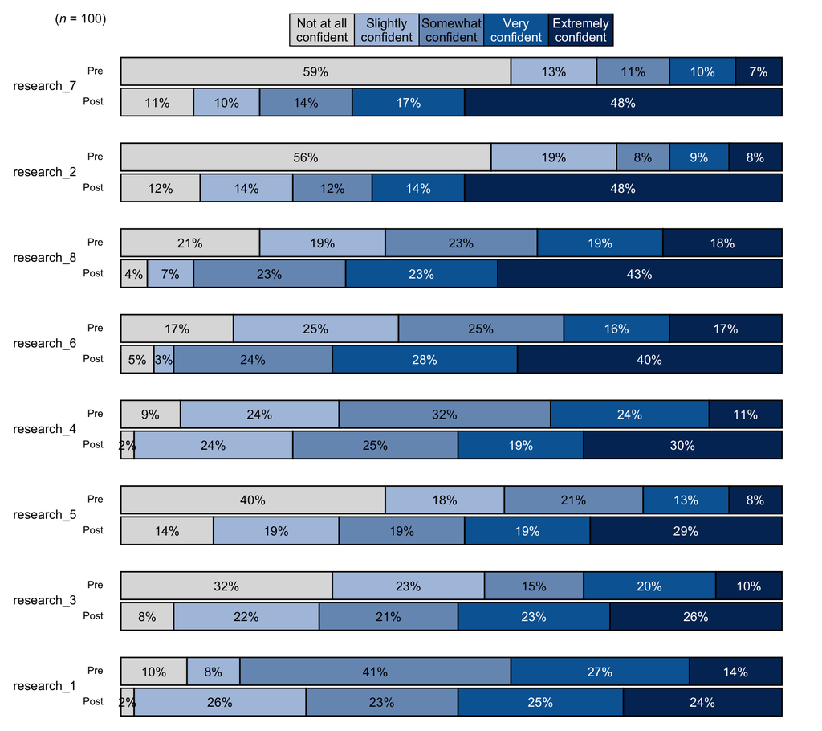

```r
# Research Items scale:
levels_confidence <- c("Not at all confident", "Slightly confident", "Somewhat confident", "Very confident", "Extremely confident")

# select variables and pass them to `stackedBarChart()` along with scale_labels.
sm_data %>% dplyr::select(tidyselect::contains("research_") & !tidyselect::contains("_num") & where(is.factor)) %>% # select the factor variables for the research items
    blackstone::stackedBarChart(., scale_labels = levels_confidence, pre_post = TRUE)
```

#### Pre-post Stacked Bar Chart with Individual Item *n* and Counts:

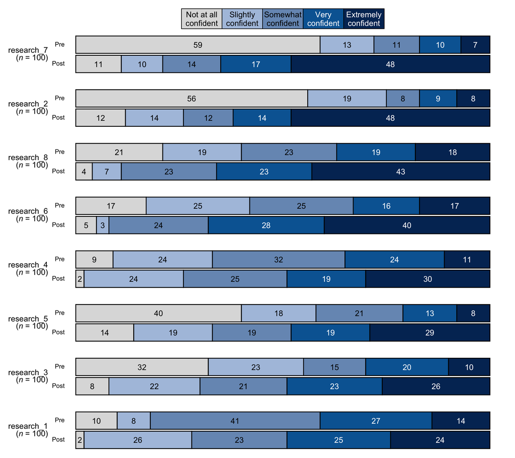

```r
# Select variables and pass them to `stackedBarChart()` along with scale_labels, change the arguements `percent_label` and `overall_n` both to FALSE:
sm_data %>% dplyr::select(tidyselect::contains("research_") & !tidyselect::contains("_num") & where(is.factor)) %>% # select the factor variables for the research items
    blackstone::stackedBarChart(., scale_labels = levels_confidence, pre_post = TRUE, percent_label = FALSE, overall_n = FALSE)
```

#### Pre-post Stacked Bar Chart with Blue-Red Diverging Color Palette:

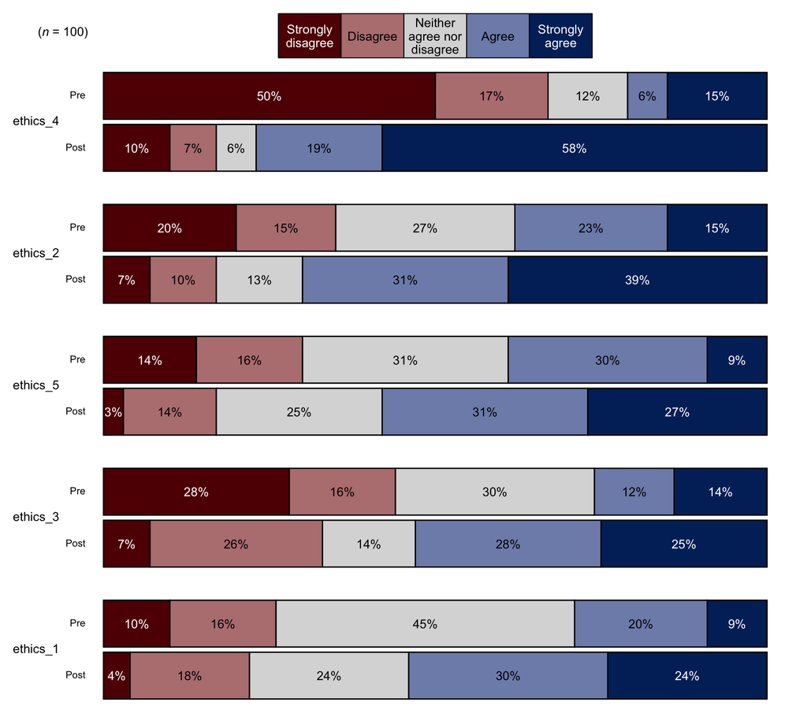

```r
## Ethics Items scale:
levels_agree5 <- c("Strongly disagree", "Disagree", "Neither agree nor disagree", "Agree", "Strongly agree")

# select variables and pass them to `stackedBarChart()` along with scale_labels,
# change `fill_colors` to "div" to use the blue-red diverging color palette:
sm_data %>% dplyr::select(tidyselect::contains("ethics_") & !tidyselect::contains("_num") & # select the factor variables for the ethics items
                              !tidyselect::contains("_oe") & where(is.factor)) %>%
            blackstone::stackedBarChart(., scale_labels = levels_agree5, pre_post = TRUE, fill_colors = "div")
```

#### Pre-post Stacked Bar Chart with New Question Labels and Order:

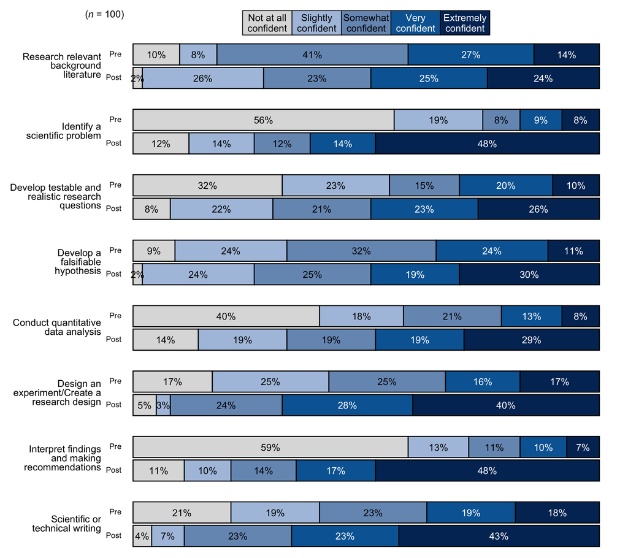

```r
# Question labels as a named vector with the naming structure
# like this: c("new label" = "original variable name"), where the
# names are the new question labels and the old names are the values without pre or post prefixes:
# Here I will use paste0 to create 8 research items like they appear without prefixes:
research_question_labels <- paste0(paste0("research_", 1:8))
# Set new labels as names of `research_question_labels`
names(research_question_labels) <- c("Research relevant background literature", "Identify a scientific problem",
                                     "Develop testable and realistic research questions", "Develop a falsifiable hypothesis",
                                     "Conduct quantitative data analysis", "Design an experiment/Create a research design",
                                     "Interpret findings and making recommendations", "Scientific or technical writing")

# select variables and pass them to `stackedBarChart()` along with scale_labels, also pass research_question_labels to `question_labels` and set `question_order` to TRUE.
sm_data %>% dplyr::select(tidyselect::contains("research_") & !tidyselect::contains("_num") & where(is.factor)) %>% # select the factor variables for the research items
    blackstone::stackedBarChart(., scale_labels = levels_confidence, pre_post = TRUE, question_labels = research_question_labels, question_order = TRUE)
```

#### Single time point Stacked Bar Chart with New Question Labels and Order:

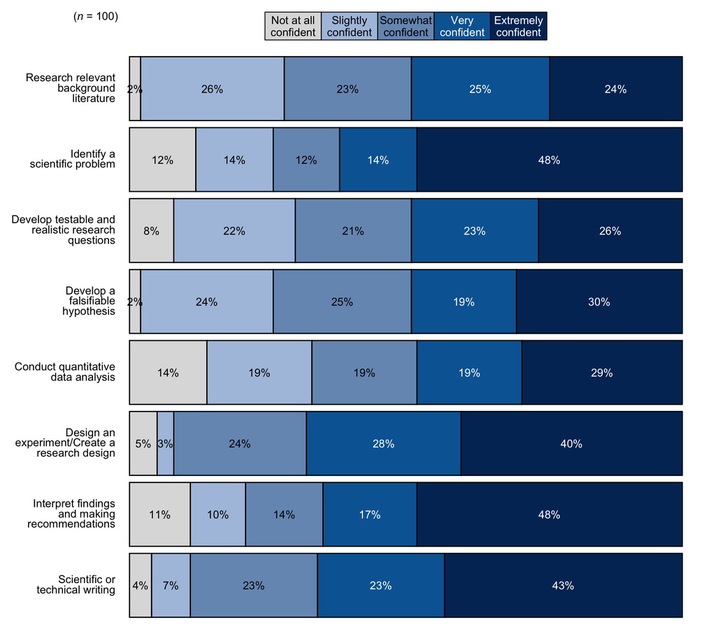

```r
# Question labels as a named vector with the naming structure
# like this: c("new label" = "original variable name"), where the
# names are the new question labels and the old names are the values without pre or post prefixes:
# Here I will use paste0 to create 8 research items like they appear without prefixes:
research_question_labels <- paste0(paste0("post_research_", 1:8))
# Set new labels as names of `research_question_labels`
names(research_question_labels) <- c("Research relevant background literature", "Identify a scientific problem",
                                     "Develop testable and realistic research questions", "Develop a falsifiable hypothesis",
                                     "Conduct quantitative data analysis", "Design an experiment/Create a research design",
                                     "Interpret findings and making recommendations", "Scientific or technical writing")

# select variables and pass them to `stackedBarChart()` along with scale_labels, set pre_post to FALSE (default),
#  also pass research_question_labels to `question_labels` and set `question_order` to TRUE.
sm_data %>% dplyr::select(tidyselect::contains("post_research_") & !tidyselect::contains("_num") & where(is.factor)) %>% # select the factor variables for the research items
    blackstone::stackedBarChart(., scale_labels = levels_confidence, question_labels = research_question_labels, question_order = TRUE)
```

## Diverging Stacked Bar Charts